# NFL_Combine_Project

### Body Composition Analysis

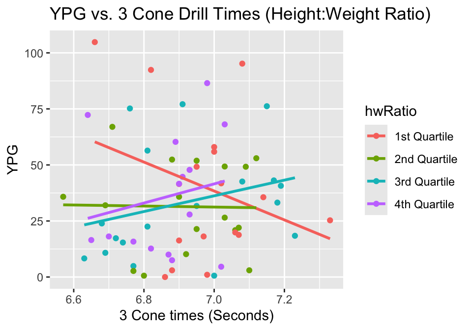

```r
ggplot(WR_Allometric, aes(x=X3cone, y=YPG,col=hwRatio)) + geom_point() +
  stat_smooth(method= "lm", se=FALSE, formula = y ~ x, aes(group = hwRatio)) +
  ggtitle("YPG vs. 3 Cone Drill Times (Height:Weight Ratio) ") +
   xlab("3 Cone times (Seconds)") + ylab("YPG") +
  theme(legend.position = "right")
```

The only relevant increase in YPG resulting from a decrease split comes in the 1st quartile. To refresh, the lower the quartile, the bulkier the frame. The 4th quartile for reference would be leaner players relative to their height. This plot suggests that there is more predictability in YPG as a result of faster 3 cone splits fro the 1st quartile. Now I’ll compare YPG predictability of the 1st quartile of Height/Weight ratio against Lengthy players.

#### YPG vs. 3 Cone Drill Times

[figure not shown]

```r
# Filter Data by Groups
WR_1Q <- WR_Allometric %>% filter(hwRatio == "1st Quartile")
WR.Heavy <- WR_Allometric %>% filter(WeightQ == "Heavy Half")

# Plots: Comparing Key Groups (Lengthy, Heavy, 1st Quartile)
g1 <- ggplot(WR.Tall, aes(x = X3cone, y = YPG)) +
  geom_point(col = "black") +
  stat_smooth(method = "lm", se = FALSE, formula = y ~ x, col = "red") +
  ggtitle("Tall WRs") +
  xlab("3-Cone Drill (Seconds)") +
  ylab("YPG")

g2 <- ggplot(WR.Heavy, aes(x = X3cone, y = YPG)) +
  geom_point(col = "blue2") +
  stat_smooth(method = "lm", se = FALSE, formula = y ~ x, col = "blue2") +
  ggtitle("Heavy WRs") +
  xlab("3-Cone Drill (Seconds)") +
  ylab("YPG")

g3 <- ggplot(WR_1Q, aes(x = X3cone, y = YPG)) +
  geom_point(col = "red2") +
  stat_smooth(method = "lm", se = FALSE, formula = y ~ x, col = "red2") +
  ggtitle("1st Quartile Height:Weight Ratio") +
  xlab("3-Cone Drill (Seconds)") +
  ylab("YPG")

grid.arrange(g1, g2, g3, ncol = 3)
```

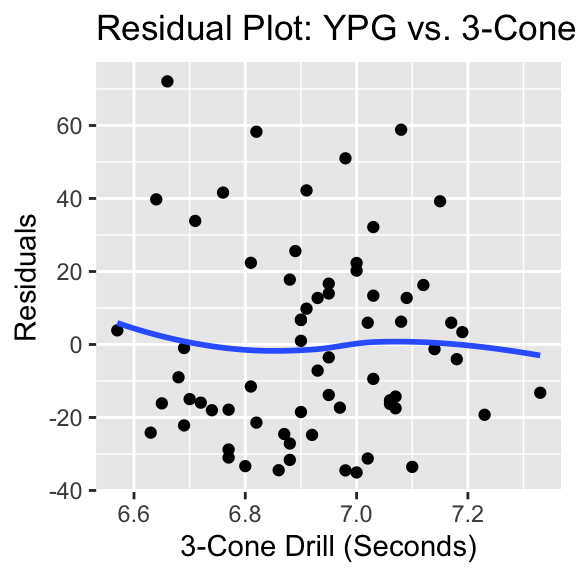

```r
# Fit the Linear Model
model1 <- lm(YPG ~ X3cone, data = WR_Allometric)

# Add Residuals to the Dataset
WR_Allometric$Residuals <- residuals(model1)

# Residual Plot: YPG vs. 3-Cone Drill
ggplot(WR_Allometric, aes(x = X3cone, y = Residuals)) +
  geom_point() +
  stat_smooth(method = "loess", se = FALSE, span = 1.5) +
  ggtitle("Residual Plot: YPG vs. 3-Cone Drill") +
  xlab("3-Cone Drill (Seconds)") +
  ylab("Residuals")
```

## Conclusion

Recapping on the flow of this report, I began interested in observing any association between the success of wide receivers in the NFL and their 40 yard dash. After learning correlation wasn’t so black and white, I began prodding at the other combine metrics, eventually measuring categories of receivers. I found that the 3 cone drill had the clearest trends, and created statistics based on players body types. In conclusion, scouts should pay closest attention to Wide Receivers’ 3 cone time’s when the player has a Height:Weight ratio in the 1st quartile of NFL receivers. If the player they are scouting does not fall within that bracket, then check for their weight percentile in relation to speed and, finally, height. For any sort wide receivers who fall outside these quartiles, I will not be able to provide any reliable, predictive statistics yet.